# Homework 9 - Alligators

Ammar Plumber, Elaina Lin, Kim Nguyen, Meghan Aines, Ryan Karbowicz

4/13/2021

# Introduction

We will be examining the difference in tweet communications between TikTok and Facebook. These are two popular social media platforms but with very different target audiences. Thus, the two brands may differ in their communication styles and language. We set out to identify the particular ways in which they differ and to build a model that can attribute each tweet to the correct user.

# Preliminary Analysis

First, we import all non-base packages to be used in this analysis.

```r
library(rtweet)
library(tidyverse)
library(lubridate)
library(scales)
library(tidytext)
library(wordcloud)
library(textdata)

library(caret)       # for general model fitting
library(rpart)       # for fitting decision trees
library(rpart.plot)
library(ipred)       # for fitting bagged decision trees
library(ranger)
library(gbm)
library(vip)

library(kableExtra)
```

Now, we import the tweets that we pulled using the get_timeline() function and saved to a CSV file. There are ~3200 tweets from each user in our dataset.

```r
# Run these two lines to get the tweets
# and then save them as a csv for future use
# tiktok <- get_timeline("tiktok_us", n=3200)
# tiktok %>% write_as_csv('tiktok.csv')
#
# facebook <- get_timeline("Facebook", n=3200)
# facebook %>% write_as_csv("facebook.csv")

tiktok <-
  read_csv('tiktok.csv') %>%
  select(status_id, source, text, created_at)

facebook <-
  read_csv('facebook.csv') %>%
  select(status_id, source, text, created_at)

nrc <- read_rds("nrc.rds")

facebook %>% head()
```

```
## # A tibble: 6 x 4
##   status_id      source    text                              created_at
##   <chr>          <chr>     <chr>                             <dttm>
## 1 x138202008034~ Twitter ~ "Ramadan Mubarak 🌙\r\~ 2021-04-13 17:17:18
## 2 x138173442901~ Khoros CX "@MeenalK1 Hi Meenal. Do you hav~ 2021-04-12 22:22:13
## 3 x138173338263~ Khoros CX "@Afrojalipro Thanks for updatin~ 2021-04-12 22:18:04
## 4 x138173266838~ Khoros CX "@CallandManning Hi Calland. If ~ 2021-04-12 22:15:14
## 5 x138171137687~ Khoros CX "@BHARTINANDAN4 Hello! Please vi~ 2021-04-12 20:50:37
## 6 x138171054847~ Khoros CX "@weathermatt22 Hi Matt. Please ~ 2021-04-12 20:47:20
```

Now, for each user, we produce a line chart showing the percent of all tweets from each source by hour.

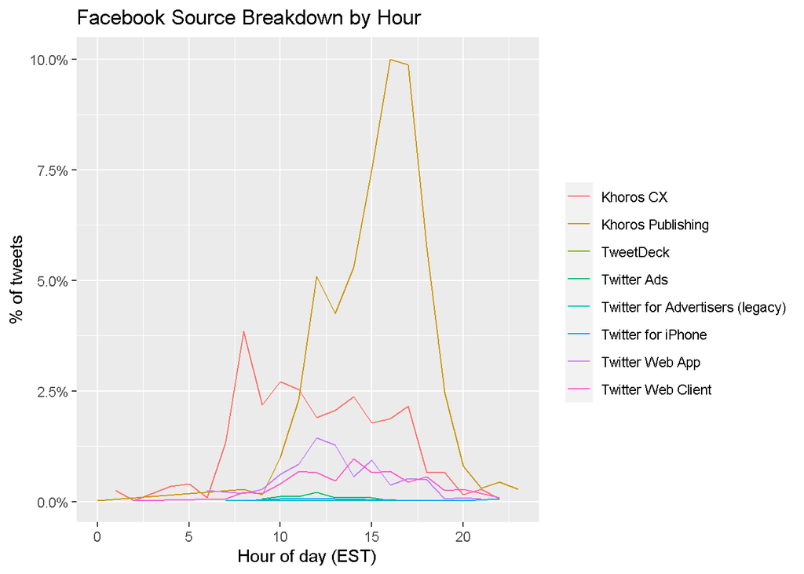

```r
facebook %>%
  count(source, hour = hour(with_tz(created_at, "EST"))) %>%
  mutate(percent = n/sum(n)) %>%
  ggplot(aes(x = hour, y = percent, color = source)) +
  labs(x = "Hour of day (EST)", y = "% of tweets", color = "") +
  scale_y_continuous(labels = percent_format()) +
  geom_line() +
  ggtitle('Facebook Source Breakdown by Hour')
```

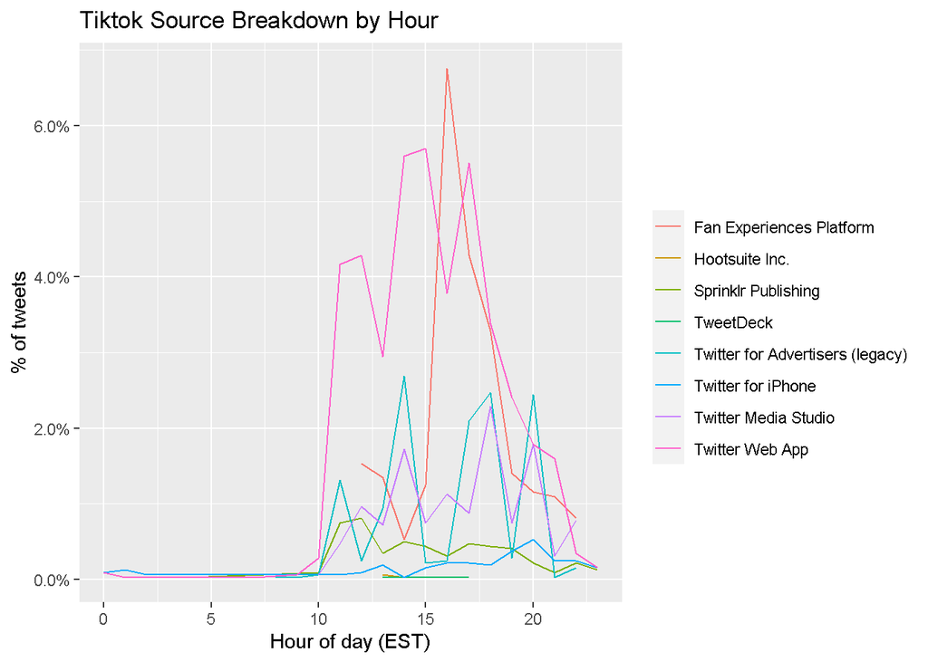

```r
tiktok %>%
  count(source, hour = hour(with_tz(created_at, "EST"))) %>%
  mutate(percent = n/sum(n)) %>%
  ggplot(aes(x = hour, y = percent, color = source)) +
  labs(x = "Hour of day (EST)", y = "% of tweets", color = "") +
  scale_y_continuous(labels = percent_format()) +
  geom_line() +
  ggtitle('Tiktok Source Breakdown by Hour')
```

We see that the vast majority of Facebook’s tweets are put out using Khoros Publishing between the hours of 10 AM and 8 PM. TikTok publishes most of its tweets through the Twitter Web App and Fan Experiences Platform—usually between 10 AM and 8 PM, like Facebook.

We want to see if both users’ tweets tend to differ in length, so we create a histogram for each user.

```r
fb_wordcounts <-
  facebook %>%
  mutate(tweetLength = str_length(text)) %>%
  filter(tweetLength < 500)

tiktok_wordcounts <-
  tiktok %>%
  mutate(tweetLength = str_length(text)) %>%
  filter(tweetLength < 500)

writeLines(c(paste0("Facebook Mean Tweet Length: ",
                  mean(fb_wordcounts$tweetLength)),
           paste0("TikTok Mean Tweet Length: ",
                  mean(tiktok_wordcounts$tweetLength))))
```

```
## Facebook Mean Tweet Length: 163.370231394622
## TikTok Mean Tweet Length: 112.916405760801
```

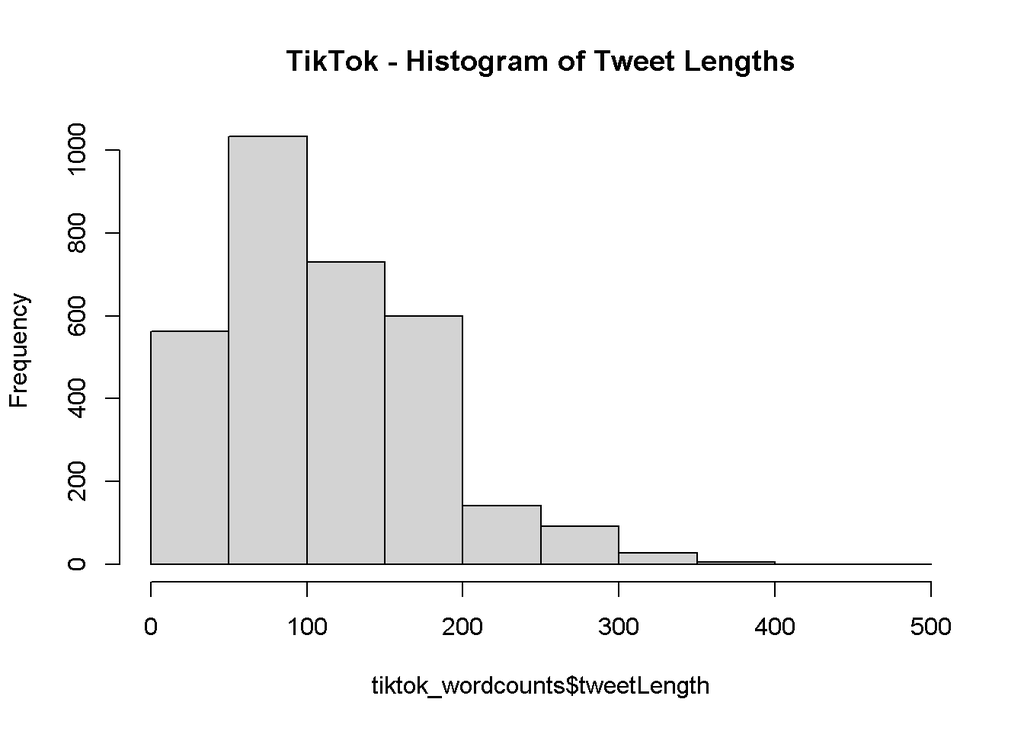

```r
hist(tiktok_wordcounts$tweetLength, main = "TikTok - Histogram of Tweet Lengths")
```

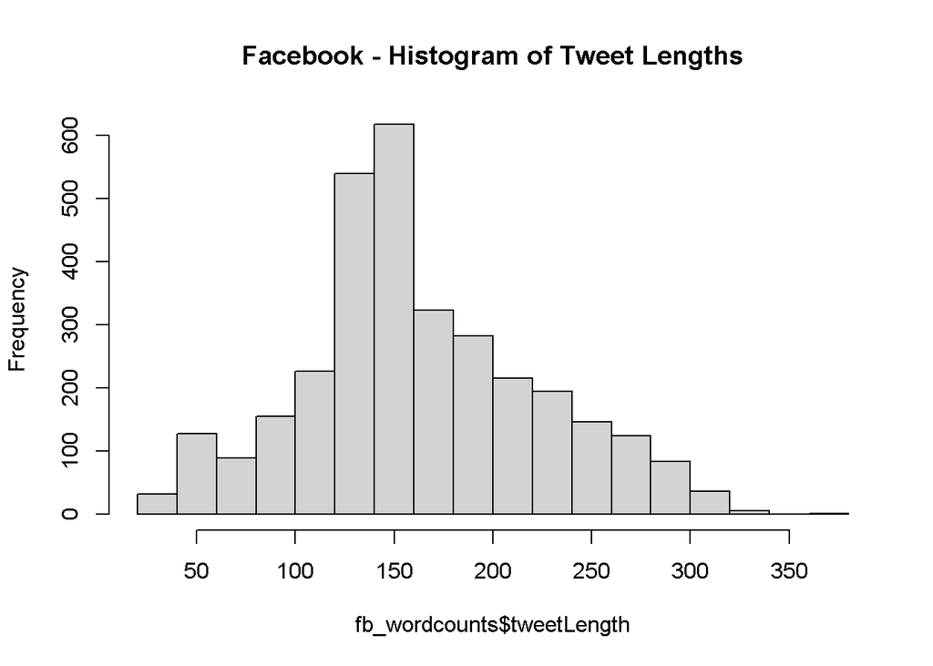

```r
hist(fb_wordcounts$tweetLength, main = "Facebook - Histogram of Tweet Lengths")
```

Next, we look at whether there is a difference in the share of Tweets that include pictures.

```r
fb_picture_counts <-
  facebook %>%
  filter(!str_detect(text, '^"')) %>%
  count(picture = ifelse(str_detect(text, "t.co"),
                         "Picture/link", "No picture/link"))

tiktok_picture_counts <-
  tiktok %>%
  filter(!str_detect(text, '^"')) %>%
  count(picture = ifelse(str_detect(text, "t.co"),
                         "Picture/link", "No picture/link"))

fb_pct_pics <-
  fb_picture_counts %>% filter(picture == "Picture/link") %>%
  select(2) %>% as.numeric() / sum(fb_picture_counts$n) * 100

tiktok_pct_pics <-
  tiktok_picture_counts %>% filter(picture == "Picture/link") %>%
  select(2) %>% as.numeric() / sum(tiktok_picture_counts$n) * 100

cat(paste0("Percent of Tweets with pictures/link\n",
           "\nFacebook: ", round(fb_pct_pics, 2),
           "\nTikTok: ", round(tiktok_pct_pics, 2)))
```

```
## Percent of Tweets with pictures/link
##
## Facebook: 85.98
## TikTok: 52.33
```

~86% of Facebook’s tweets contain pictures/links, while only ~52% of TikTok’s tweets contain pictures/links. This could be another useful predictor to include in our model.

# Sentiment Analysis

Now, we split the tweets into tokens so that we can perform sentiment analysis on them.

```r
reg <- "([^A-Za-z\\d#@']|'(?![A-Za-z\\d#@]))"

# Unnest the text strings into a data frame of words
fb_words <-
  facebook %>%
  filter(!str_detect(text, '^"')) %>%
  mutate(text = str_replace_all(text,
                                "https://t.co/[A-Za-z\\d]+|&amp;",
                                "")) %>%
  unnest_tokens(word, text,
                token = "regex",
                pattern = reg) %>%
  filter(!word %in% stop_words$word,
         str_detect(word, "[a-z]"))

tiktok_words <-
  tiktok %>%
  filter(!str_detect(text, '^"')) %>%
  mutate(text = str_replace_all(text,
                                "https://t.co/[A-Za-z\\d]+|&amp;",
                                "")) %>%
  unnest_tokens(word, text,
                token = "regex",
                pattern = reg) %>%
  filter(!word %in% stop_words$word,
         str_detect(word, "[a-z]"))

# Inspect the first six rows of tweet_words
head(fb_words)
```

```
## # A tibble: 6 x 4
##   status_id            source          created_at          word
##   <chr>                <chr>           <dttm>              <chr>
## 1 x1382020080343470082 Twitter Web App 2021-04-13 17:17:18 ramadan
## 2 x1382020080343470082 Twitter Web App 2021-04-13 17:17:18 mubarak
## 3 x1382020080343470082 Twitter Web App 2021-04-13 17:17:18 0001f319
## 4 x1382020080343470082 Twitter Web App 2021-04-13 17:17:18 #monthofgood
## 5 x1382020080343470082 Twitter Web App 2021-04-13 17:17:18 check
## 6 x1382020080343470082 Twitter Web App 2021-04-13 17:17:18 kindness
```

We produce two horizontal bar graphs that show the most common words along with a wordcloud for each user.

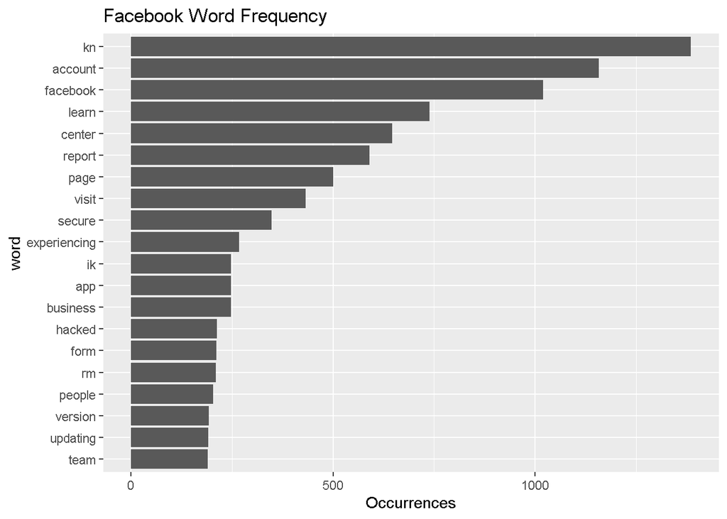

```r
fb_words %>%
  count(word, sort = TRUE) %>%
  head(20) %>%
  mutate(word = reorder(word, n)) %>%
  ggplot(aes(x = word, y = n)) +
  geom_bar(stat = "identity") +
  ylab("Occurrences") +
  coord_flip() +
  ggtitle("Facebook Word Frequency")
```

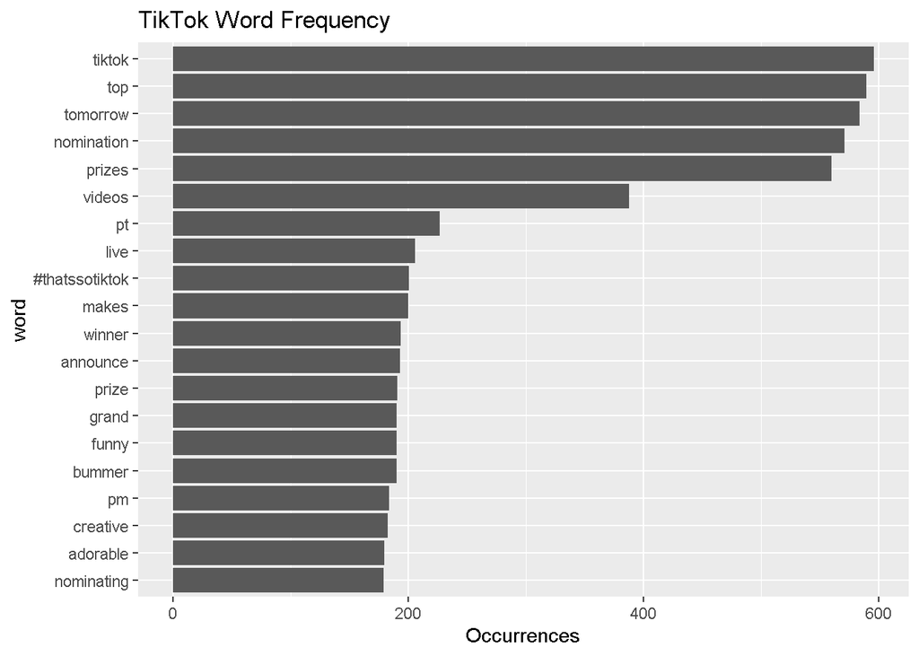

```r
tiktok_words %>%
  count(word, sort = TRUE) %>%
  head(20) %>%
  mutate(word = reorder(word, n)) %>%
  ggplot(aes(x = word, y = n)) +
  geom_bar(stat = "identity") +
  ylab("Occurrences") +
  coord_flip() +
  ggtitle("TikTok Word Frequency")
```

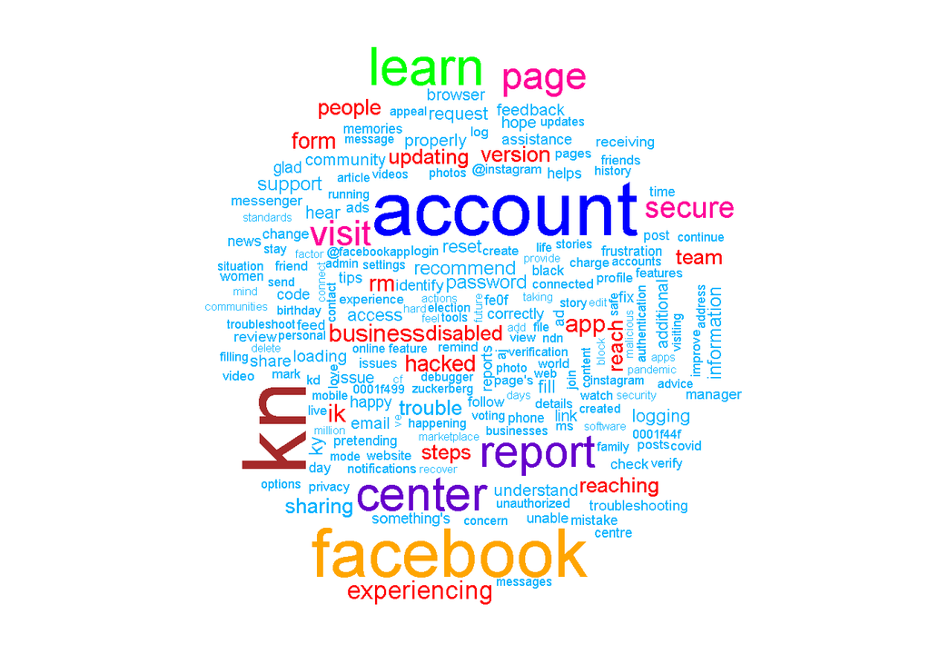

```r
facebook_cloud <-
  fb_words  %>%
  count(word) %>%
  arrange(-n)

wordcloud(facebook_cloud$word,
          facebook_cloud$n, max.words = 200,
          colors = c("#00B2FF", "red",
                     "#FF0099", "#6600CC",
                     "green", "orange",
                     "blue", "brown"))
```

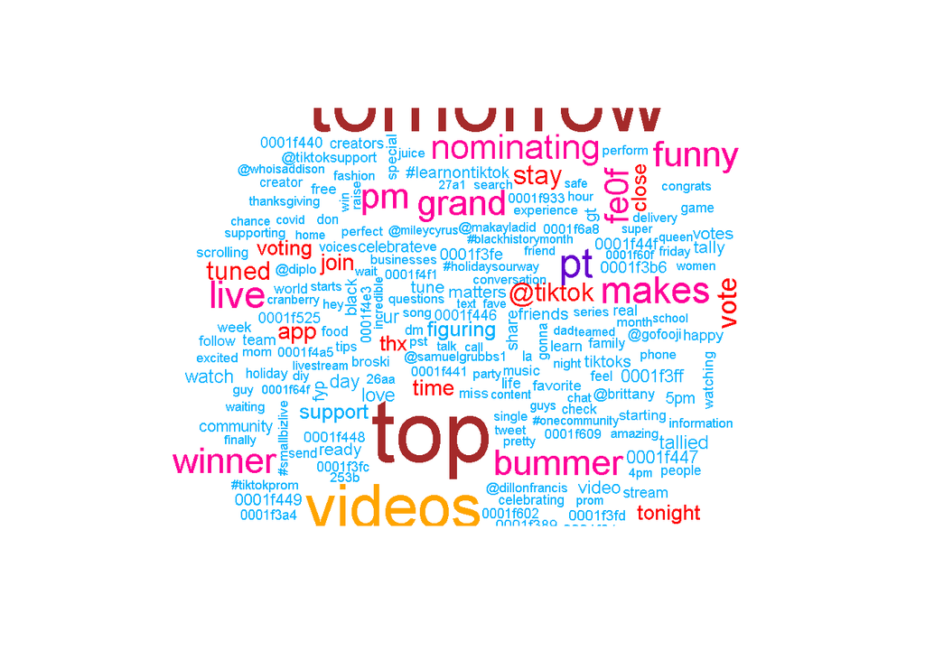

```r
tiktok_cloud <-
  tiktok_words  %>%
  count(word) %>%
  arrange(-n)

wordcloud(tiktok_cloud$word,
          tiktok_cloud$n, max.words = 200,
          colors = c("#00B2FF", "red",
                     "#FF0099", "#6600CC",
                     "green", "orange",
                     "blue", "brown"))
```

We join the NRC Word-Emotion Association Lexicon to our data, which will allow us to identify words associated with eight basic emotions (anger, fear, anticipation, trust, surprise, sadness, joy, and disgust) and two sentiments (negative and positive).

```r
fb_sentiment <-
  inner_join(fb_words, nrc, by = "word") %>%
  group_by(sentiment)

tiktok_sentiment <-
  inner_join(tiktok_words, nrc, by = "word") %>%
  group_by(sentiment)

fb_sentiment %>% head()
```

```
## # A tibble: 6 x 5
## # Groups:   sentiment [4]
##   status_id            source          created_at          word      sentiment
##   <chr>                <chr>           <dttm>              <chr>     <chr>
## 1 x1382020080343470082 Twitter Web App 2021-04-13 17:17:18 kindness  positive
## 2 x1381733382632001536 Khoros CX       2021-04-12 22:18:04 happy     anticipati~
## 3 x1381733382632001536 Khoros CX       2021-04-12 22:18:04 happy     joy
## 4 x1381733382632001536 Khoros CX       2021-04-12 22:18:04 happy     positive
## 5 x1381733382632001536 Khoros CX       2021-04-12 22:18:04 happy     trust
## 6 x1381733382632001536 Khoros CX       2021-04-12 22:18:04 wonderful joy
```

Here, we compare Facebook’s and TikTok’s sentiments.

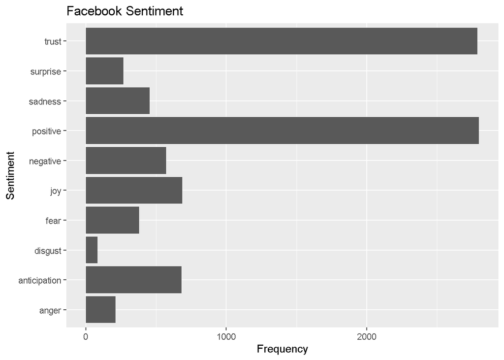

```r
fb_sentiment_analysis <-
  fb_sentiment %>%
  count(word, sentiment) %>%
  group_by(sentiment)

fb_sentiment_analysis %>%
  top_n(15) %>%
  ggplot(aes(x = sentiment, y = n )) +
  geom_bar(stat = "identity") +
  coord_flip() +
  ylab("Frequency") +
  xlab("Sentiment") +
  labs(title="Facebook Sentiment")
```

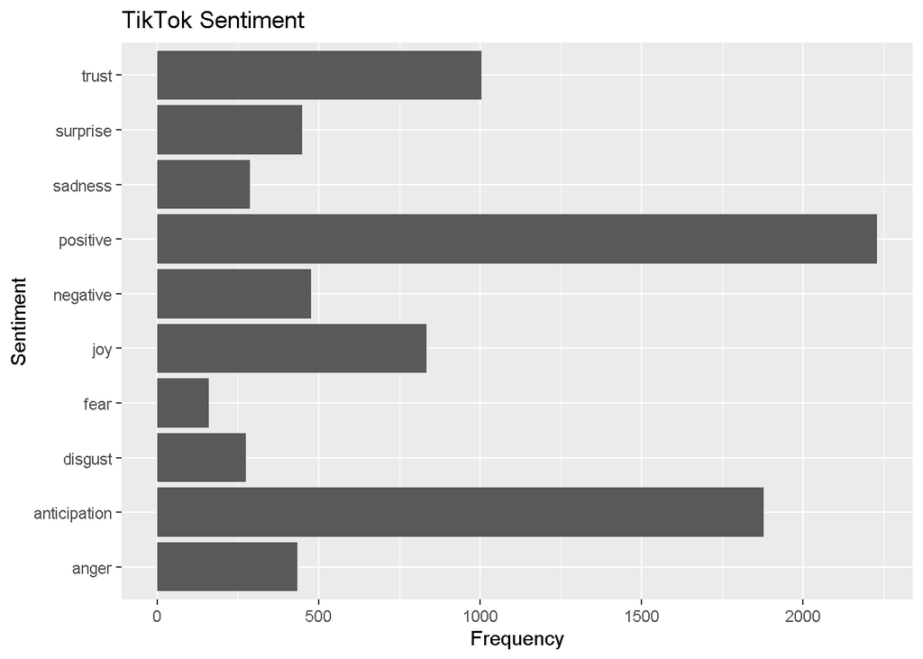

```r
tiktok_sentiment_analysis <-
  tiktok_sentiment %>%
  count(word, sentiment) %>%
  group_by(sentiment)

tiktok_sentiment_analysis %>%
  top_n(15) %>%
  ggplot(aes(x = sentiment, y = n )) +
  geom_bar(stat = "identity") +
  coord_flip() +
  ylab("Frequency") +
  xlab("Sentiment") +
  labs(title="TikTok Sentiment")
```

It looks like Facebook’s tweets use more trust words while TikTok uses more words that reflect anticipation. We now show specifically which words are conveying each of these observed sentiments.

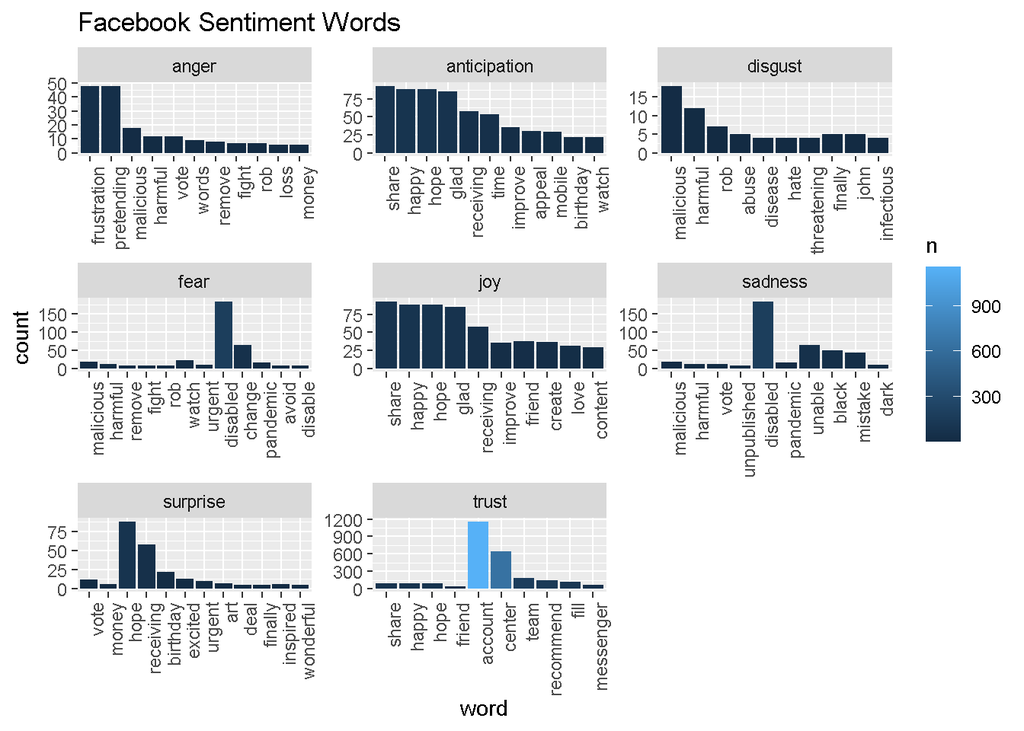

```r
fb_sentiment_analysis %>% filter(!sentiment %in% c("positive", "negative")) %>%
  mutate(sentiment = reorder(sentiment, -n),
         word = reorder(word, -n)) %>% top_n(10) -> fb_sentiment_analysis2

ggplot(fb_sentiment_analysis2, aes(x=word, y=n, fill = n)) +
  facet_wrap(~ sentiment, scales = "free")+
  geom_bar(stat ="identity") +
  theme(axis.text.x = element_text(angle = 90, hjust = 1)) +
  labs(y="count", title="Facebook Sentiment Words")
```

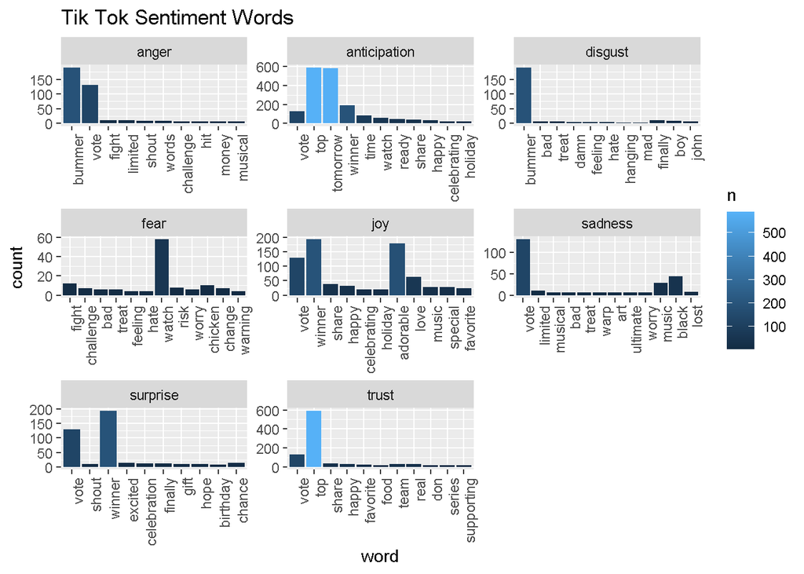

```r
tiktok_sentiment_analysis %>% filter(!sentiment %in% c("positive", "negative")) %>%
  mutate(sentiment = reorder(sentiment, -n),
         word = reorder(word, -n)) %>% top_n(10) -> tiktok_sentiment_analysis2

ggplot(tiktok_sentiment_analysis2, aes(x=word, y=n, fill = n)) +
  facet_wrap(~ sentiment, scales = "free")+
  geom_bar(stat ="identity") +
  theme(axis.text.x = element_text(angle = 90, hjust = 1)) +
  labs(y="count", title="Tik Tok Sentiment Words")
```

Next, we examine texts on Facebook and Tiktok to see their positive-negative score by using the AFINN sentiment lexicon, a list of English terms manually rated for valence with an integer between -5 (negative) and +5 (positive) by Finn Årup Nielsen between 2009 and 2011.

We use this lexicon to compute mean positivity scores for all words tweeted by each user.

```r
# run this to get afinn lexicon and save it as a csv
# get_sentiments ("afinn") -> afinn
#
#afinn %>% write_as_csv("afinn.csv")

afinn <- read_csv('afinn.csv')

fb_afinn <-
 inner_join(fb_words,
            afinn,
            by = "word")

tiktok_afinn <-
 inner_join(tiktok_words,
            afinn,
            by = "word")

fb_mean_afinn <-
  fb_afinn %>%
  summarise(mean_fb_afinn = mean(value))

tiktok_mean_afinn <-
  tiktok_afinn %>%
  summarise(mean_tt_afinn = mean(value))

cat(paste0("Average AFINN scores for all words by user\n",
           "\nFacebook: ", round(fb_mean_afinn, 3),
           "\nTikTok: ", round(tiktok_mean_afinn, 3)))
```

```
## Average AFINN scores for all words by user
##
## Facebook: 0.785
## TikTok: 1.704
```

Facebook’s mean AFINN value is 0.79 while TikTok’s mean AFINN value is 1.704. In general, words tweeted by Tiktok are more positive than those tweeted by Facebook.

# Training Predictive Models

Here, using the text of a tweet, we attempt to predict the user who tweeted it.

The features we extracted are tweet length, the presence of a picture/link, number of words for each sentiment, and mean AFINN score per tweet.

TikTok is encoded as 1, and Facebook is encoded as 0.

First, we produce a simple decision tree.

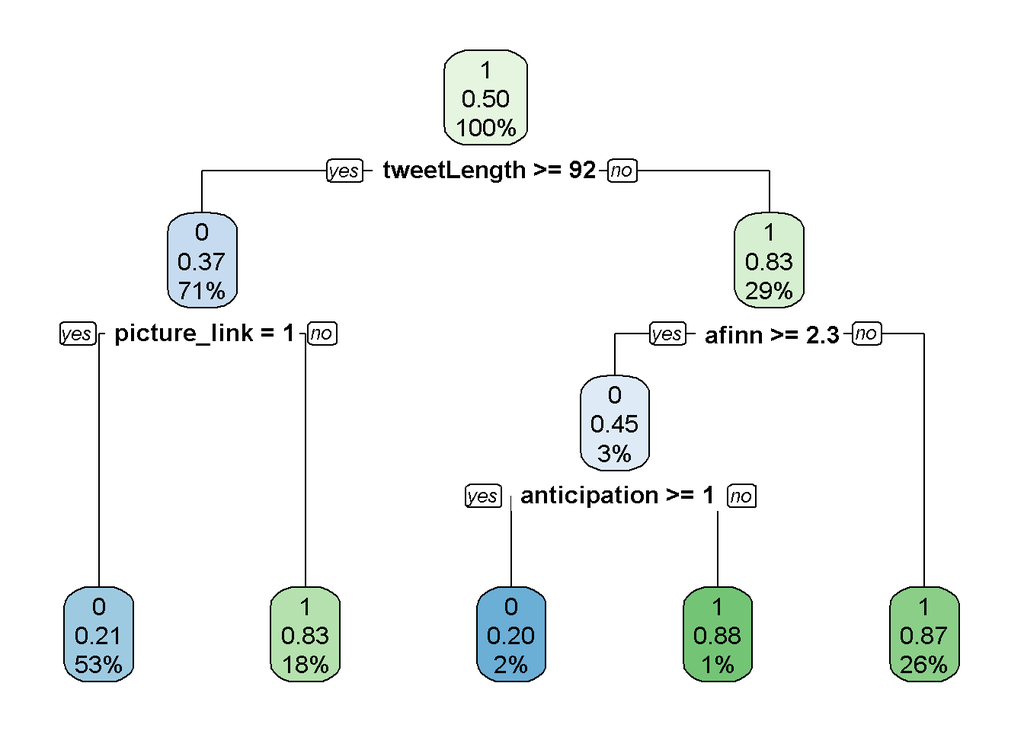

```r
fb_piclinks <-
  facebook %>%
  filter(!str_detect(text, '^"')) %>%
  mutate(picture_link = ifelse(str_detect(text, "t.co"),
                         1, 0)) %>%
  select(1,5)

tiktok_piclinks <-
  tiktok %>%
  filter(!str_detect(text, '^"')) %>%
  mutate(picture_link = ifelse(str_detect(text, "t.co"),
                         1, 0)) %>%
  select(1,5)

fb_tweet_afinn <-
  fb_afinn %>%
  group_by(status_id) %>%
  summarize(afinn = mean(value))

tiktok_tweet_afinn <-
  tiktok_afinn %>%
  group_by(status_id) %>%
  summarize(afinn = mean(value))

fb_sentiment_counts <-
  fb_sentiment %>%
  group_by(status_id) %>%
  count(sentiment) %>%
  pivot_wider(id_cols = status_id,
              names_from = sentiment,
              values_from = n,
              values_fill = 0)

tiktok_sentiment_counts <-
  tiktok_sentiment %>%
  group_by(status_id) %>%
  count(sentiment) %>%
  pivot_wider(id_cols = status_id,
              names_from = sentiment,
              values_from = n,
              values_fill = 0)

tiktok_feature_selection <-
  tiktok_wordcounts %>%
  mutate(user = 1) %>%
  left_join(tiktok_sentiment_counts,
            by="status_id") %>%
  left_join(tiktok_tweet_afinn,
            by="status_id") %>%
  left_join(tiktok_piclinks,
            by="status_id")

facebook_feature_selection <-
  fb_wordcounts %>%
  mutate(user = 0) %>%
  left_join(fb_sentiment_counts,
            by="status_id") %>%
  left_join(fb_tweet_afinn,
            by="status_id") %>%
  left_join(fb_piclinks,
            by="status_id")

both_users <-
  tiktok_feature_selection %>%
  rbind(facebook_feature_selection) %>%
  mutate_if(is.numeric,coalesce,0)

set.seed(123)
index <-
  createDataPartition(both_users$user,
                      p = 0.8, list = FALSE)

for_decisiontree <-
  both_users %>% select(-1,-2,-3,-4) %>%
  drop_na()

train <- for_decisiontree[index, ]
test  <- for_decisiontree[-index, ]

set.seed(123)
simple_model <- rpart(user ~ .,
                      data = train, method = "class")
rpart.plot(simple_model, yesno = 2)
```

We produce additional models using the bagging, random forests, and gradient boosting methods.

```r
set.seed(123)
bagging_model <- train(
  user ~ .,
  data = train,
  method = "treebag",
  trControl = trainControl(method = "oob"),
  keepX = T,
  nbagg = 100,
  importance = "impurity",
  control = rpart.control(minsplit = 2, cp = 0)
)

n_features <- length(setdiff(names(train), "user"))

rf_model <- ranger(
  user ~ .,
  data = train,
  mtry = floor(n_features * 0.5),
  respect.unordered.factors = "order",
  importance = "permutation",
  seed = 123
)


set.seed(123)  # for reproducibility
gbm_model <- gbm(
  formula = user ~ .,
  data = train,
  distribution = "gaussian",  # SSE loss function
  n.trees = 1000,
  shrinkage = 0.05,
  interaction.depth = 5,
  n.minobsinnode = 4,
  cv.folds = 10
)
```

We also display four variable importance plots to see which variables each model identified as significant.

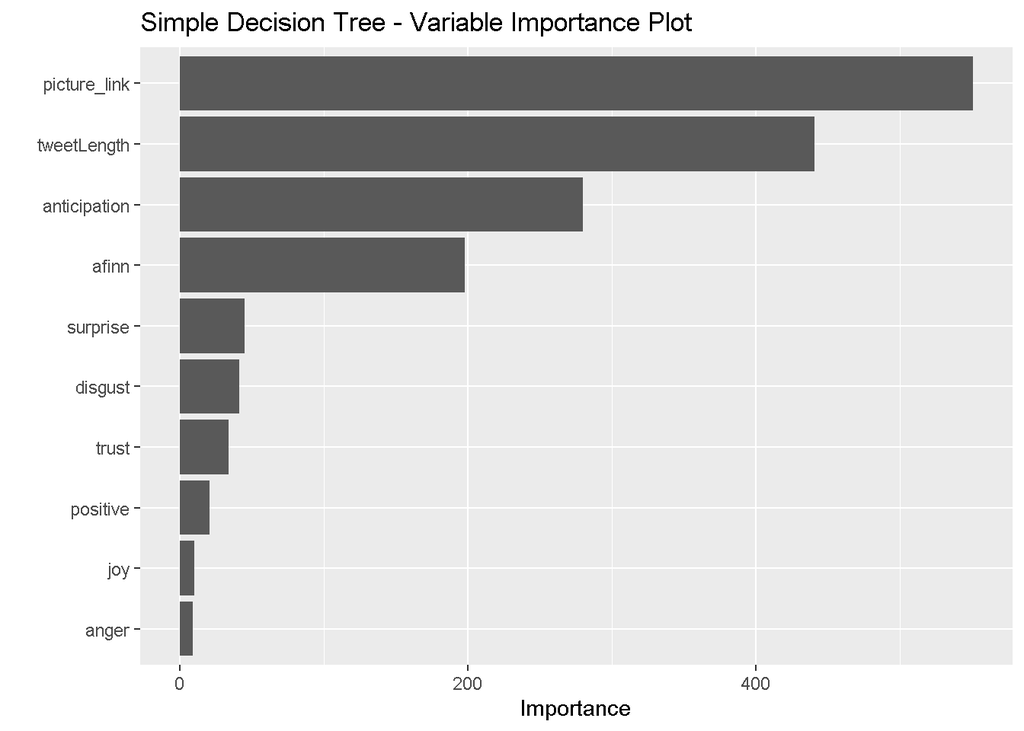

```r
vip(simple_model, num_features = 30) + ggtitle('Simple Decision Tree - Variable Importance Plot')
```

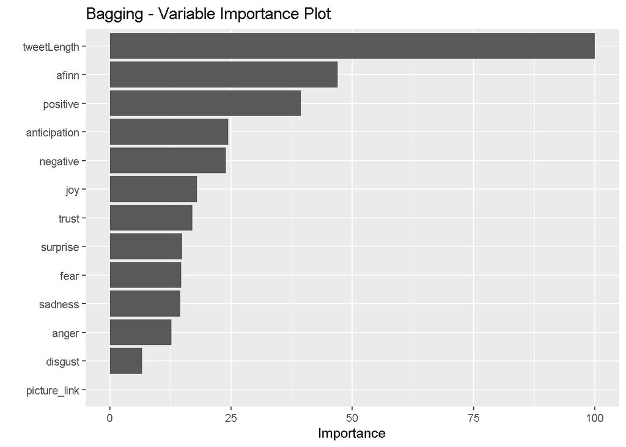

```r
vip(bagging_model, num_features = 30) + ggtitle('Bagging - Variable Importance Plot')
```

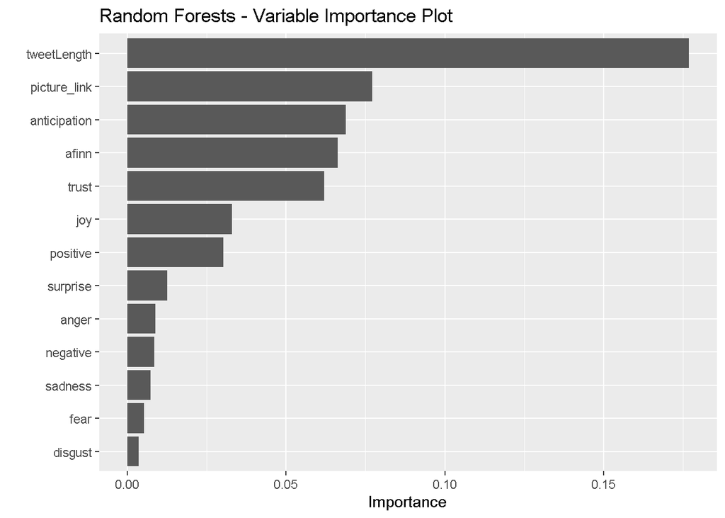

```r
vip(rf_model, num_features = 30) + ggtitle('Random Forests - Variable Importance Plot')
```

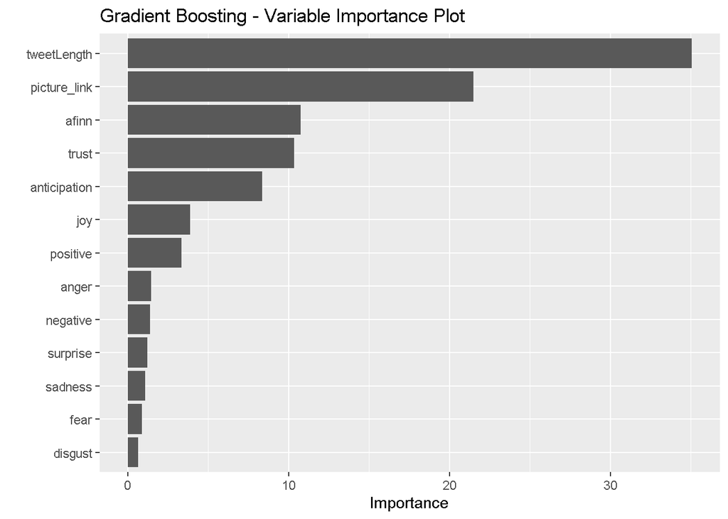

```r
vip(gbm_model, num_features = 30) + ggtitle('Gradient Boosting - Variable Importance Plot')
```

It seems that the simple decision tree placed the most importance on the presence of a picture/link. The bagging model, on the other hand places no importance on this variable. All four methods identified tweet length as strongly predictive of the user. All four heavily weighted anticipation sentiments and AFINN scores.

# Results and Discussion

## Training Set Performance

**Simple Decision Tree - Training Set:**

```
## Confusion Matrix and Statistics
##
##           Reference
## Prediction    0    1
##          0 2215  583
##          1  332 1984
##
##                Accuracy : 0.8211
##                  95% CI : (0.8103, 0.8315)
##     No Information Rate : 0.502
##     P-Value [Acc > NIR] : < 2.2e-16
##
##                   Kappa : 0.6423
##
##  Mcnemar's Test P-Value : < 2.2e-16
##
##               Precision : 0.7916
##                  Recall : 0.8697
##                      F1 : 0.8288
##              Prevalence : 0.4980
##          Detection Rate : 0.4331
##    Detection Prevalence : 0.5471
##       Balanced Accuracy : 0.8213
##
##        'Positive' Class : 0
##
```

**Bagging Method - Training Set:**

```
## Confusion Matrix and Statistics
##
##           Reference
## Prediction    0    1
##          0 2458   57
##          1   89 2510
##
##                Accuracy : 0.9715
##                  95% CI : (0.9665, 0.9758)
##     No Information Rate : 0.502
##     P-Value [Acc > NIR] : <2e-16
##
##                   Kappa : 0.9429
##
##  Mcnemar's Test P-Value : 0.0103
##
##               Precision : 0.9773
##                  Recall : 0.9651
##                      F1 : 0.9712
##              Prevalence : 0.4980
##          Detection Rate : 0.4806
##    Detection Prevalence : 0.4918
##       Balanced Accuracy : 0.9714
##
##        'Positive' Class : 0
##
```

**Random Forests Method - Training Set:**

```
## Confusion Matrix and Statistics
##
##           Reference
## Prediction    0    1
##          0 2410   99
##          1  137 2468
##
##                Accuracy : 0.9539
##                  95% CI : (0.9477, 0.9594)
##     No Information Rate : 0.502
##     P-Value [Acc > NIR] : < 2e-16
##
##                   Kappa : 0.9077
##
##  Mcnemar's Test P-Value : 0.01602
##
##               Precision : 0.9605
##                  Recall : 0.9462
##                      F1 : 0.9533
##              Prevalence : 0.4980
##          Detection Rate : 0.4713
##    Detection Prevalence : 0.4906
##       Balanced Accuracy : 0.9538
##
##        'Positive' Class : 0
##
```

**Gradient Boosting Method - Training Set:**

```
## Using 806 trees...
```

```
## Confusion Matrix and Statistics
##
##           Reference
## Prediction    0    1
##          0 2297  303
##          1  250 2264
##
##                Accuracy : 0.8919
##                  95% CI : (0.883, 0.9002)
##     No Information Rate : 0.502
##     P-Value [Acc > NIR] : < 2e-16
##
##                   Kappa : 0.7837
##
##  Mcnemar's Test P-Value : 0.02702
##
##               Precision : 0.8835
##                  Recall : 0.9018
##                      F1 : 0.8926
##              Prevalence : 0.4980
##          Detection Rate : 0.4492
##    Detection Prevalence : 0.5084
##       Balanced Accuracy : 0.8919
##
##        'Positive' Class : 0
##
```

**Performance Summary and RSS**

| type | total_errors | accuracy |
| --- | --- | --- |
| Simple | 915 | 0.8210794 |
| Bagging | 146 | 0.9714509 |
| Random Forests | 236 | 0.9538522 |
| Gradient Boosting | 553 | 0.8918655 |

The rankings for accuracy on the training set are as follows: 1. Bagging method 2. Random forests 3. Gradient boosting method 4. Simple decision tree

We show the residual sum of squares for all four models on the training set below.

```r
rss_simple_train <- sum((actual_train-simple_pred_train)^2)
rss_bagging_train <- sum((actual_train-bagging_pred_train)^2)
rss_rf_train <- sum((actual_train-rf_pred_train)^2)
rss_gb_train <- sum((actual_train-gb_pred_train)^2)

cat(paste0("Residual Sum of Squares on Training Set\n",
           "\nSimple model: ", rss_simple_train,
           "\nBagging model: ", rss_bagging_train,
           "\nRandom forests model: ", rss_rf_train,
           "\nGradient boosting model: ", rss_gb_train))
```

```
## Residual Sum of Squares on Training Set
##
## Simple model: 744.823130490417
## Bagging model: 148.955784690615
## Random forests model: 226.599946610086
## Gradient boosting model: 407.58762929458
```

The bagging model performed the best on the training set, followed by the random forests method, the gradient boosting method, and the simple model in last place.

Now, we show confusion matrices for the test set.

## Test Set Performance

**Simple Decision Tree - Test Set:**

```r
actual_test <- test$user

simple_pred_test <-
  predict(simple_model, newdata = test) %>%
  as_tibble() %>%
  select(2) %>%
  unlist() %>%
  as.vector()

simple_test_confusion <-
  confusionMatrix(data = factor(round(simple_pred_test)),
                  reference = factor(actual_test), mode = "prec_recall")

simple_test_errors <-
  simple_test_confusion$table[2] +
  simple_test_confusion$table[3]

simple_test_accuracy <-
  as.numeric(simple_test_confusion$overall[1])

simple_test_confusion
```

```
## Confusion Matrix and Statistics
##
##           Reference
## Prediction   0   1
##          0 562 138
##          1  89 489
##
##                Accuracy : 0.8224
##                  95% CI : (0.8003, 0.843)
##     No Information Rate : 0.5094
##     P-Value [Acc > NIR] : < 2.2e-16
##
##                   Kappa : 0.6441
##
##  Mcnemar's Test P-Value : 0.001443
##
##               Precision : 0.8029
##                  Recall : 0.8633
##                      F1 : 0.8320
##              Prevalence : 0.5094
##          Detection Rate : 0.4397
##    Detection Prevalence : 0.5477
##       Balanced Accuracy : 0.8216
##
##        'Positive' Class : 0
##
```

**Bagging Method - Test Set:**

```
## Confusion Matrix and Statistics
##
##           Reference
## Prediction   0   1
##          0 550  92
##          1 101 535
##
##                Accuracy : 0.849
##                  95% CI : (0.8282, 0.8682)
##     No Information Rate : 0.5094
##     P-Value [Acc > NIR] : <2e-16
##
##                   Kappa : 0.6979
##
##  Mcnemar's Test P-Value : 0.5647
##
##               Precision : 0.8567
##                  Recall : 0.8449
##                      F1 : 0.8507
##              Prevalence : 0.5094
##          Detection Rate : 0.4304
##    Detection Prevalence : 0.5023
##       Balanced Accuracy : 0.8491
##
##        'Positive' Class : 0
##
```

**Random Forests Method - Test Set:**

```
## Confusion Matrix and Statistics
##
##           Reference
## Prediction   0   1
##          0 567  87
##          1  84 540
##
##                Accuracy : 0.8662
##                  95% CI : (0.8463, 0.8844)
##     No Information Rate : 0.5094
##     P-Value [Acc > NIR] : <2e-16
##
##                   Kappa : 0.7323
##
##  Mcnemar's Test P-Value : 0.8784
##
##               Precision : 0.8670
##                  Recall : 0.8710
##                      F1 : 0.8690
##              Prevalence : 0.5094
##          Detection Rate : 0.4437
##    Detection Prevalence : 0.5117
##       Balanced Accuracy : 0.8661
##
##        'Positive' Class : 0
##
```

**Gradient Boosting Method - Test Set:**

```
## Using 806 trees...
```

```
## Confusion Matrix and Statistics
##
##           Reference
## Prediction   0   1
##          0 568  93
##          1  83 534
##
##                Accuracy : 0.8623
##                  95% CI : (0.8422, 0.8807)
##     No Information Rate : 0.5094
##     P-Value [Acc > NIR] : <2e-16
##
##                   Kappa : 0.7244
##
##  Mcnemar's Test P-Value : 0.4975
##
##               Precision : 0.8593
##                  Recall : 0.8725
##                      F1 : 0.8659
##              Prevalence : 0.5094
##          Detection Rate : 0.4444
##    Detection Prevalence : 0.5172
##       Balanced Accuracy : 0.8621
##
##        'Positive' Class : 0
##
```

**Performance Summary and RSS**

| type | total_errors | accuracy |
| --- | --- | --- |
| Simple | 227 | 0.8223787 |
| Bagging | 193 | 0.8489828 |
| Random Forests | 171 | 0.8661972 |
| Gradient Boosting | 176 | 0.8622848 |

The rankings for accuracy on the test set are as follows:

1. Random forests
2. Gradient boosting method
3. Bagging method
4. Simple decision tree

Now, we show the residual sum of squares for each model with respect to the test set.

```r
rss_simple_test <- sum((actual_test-simple_pred_test)^2)
rss_bagging_test <- sum((actual_test-bagging_pred_test)^2)
rss_rf_test <- sum((actual_test-rf_pred_test)^2)
rss_gb_test <- sum((actual_test-gb_pred_test)^2)

cat(paste0("Residual Sum of Squares on Test Set\n",
           "\nSimple model: ", rss_simple_test,
           "\nBagged model: ", rss_bagging_test,
           "\nRandom forests model: ", rss_rf_test,
           "\nGradient boost model: ", rss_gb_test))
```

```
## Residual Sum of Squares on Test Set
##
## Simple model: 185.903238689494
## Bagged model: 137.082023601223
## Random forests model: 120.747112472235
## Gradient boost model: 132.480675055803
```

The random forests model performed the best on the test set even though it was only second best for the training set. However, that may be an indication that the bagging model was overfit to the training data, which caused it to perform worse on the test set than the random forests model.

In sum, it seems that the best model is the random forests model, with a test set accuracy score of 86.62%.

# Conclusion

Looking at the analyses, it seems that the Facebook and TikTok accounts have systematically different Twitter presences. Facebook seems to respond more frequently to user fears, which are associated with words such as “secure” and “trust.” Whereas, TikTok focuses on generating excitement and offer prize giveaways, which is associated with “anticipation” words such as “winning” and “tomorrow.” Differences in tweet length also possibly reflect on the preferences of the target audience; TikTok users are younger and less likely to consume written information (it is a video platform, after all), and the opposite is true for Facebook. In sum, our predictive endeavor was successful, and we unveiled a number of useful insights from it.